# NLP and Python

### Python Users Berlin 29.9.2015

- Matti Lyra
- @mattilyra
- https://github.com/mattilyra/PUB_nlp

# University of Sussex

## Text Analytics Lab

- 5 years old
- 7 PhD Students
- 4 Research Fellows
- Active in academic research and industrial applications

# Python and NLP

### http://www.nltk.org/book/

- `NLTK` / `spacy` / `sklearn` / `gensim`
- An overview of NLP tools in Python
  - strings to things (segmentation, tokenisation, text normalisation)
  - feature frequencies (TF-IDF, smoothing)
  - part-of-speech tagging
  - document classification (sentiment analysis)
  - information extraction
  - topic modelling
  - language models / deep learning

```python
lipsum = "Lorem Ipsum is simply dummy text of the printing and typesetting industry. Lorem Ipsum has been the industry's standard dummy text ever since the 1500s, when an unknown printer took a galley of type and scrambled it to make a type specimen book."
```

```python
from string import ascii_lowercase as lc
lfmprj = ''.join([lc[lc.index(c) - 3] if c in set(lc)
                                      else c
                  for c in lipsum])
lfmprj
```

```
"Llobj Imprj fp pfjmiv arjjv qbuq lc qeb mofkqfkd xka qvmbpbqqfkd fkarpqov. Llobj Imprj exp ybbk qeb fkarpqov'p pqxkaxoa arjjv qbuq bsbo pfkzb qeb 1500p, tebk xk rkhkltk mofkqbo qllh x dxiibv lc qvmb xka pzoxjyiba fq ql jxhb x qvmb pmbzfjbk yllh."
```

```python
from nltk.tokenize import sent_tokenize

sentences = sent_tokenize(lfmprj)
sentences[:5]
```

```
['Llobj Imprj fp pfjmiv arjjv qbuq lc qeb mofkqfkd xka qvmbpbqqfkd fkarpqov.',
 "Llobj Imprj exp ybbk qeb fkarpqov'p pqxkaxoa arjjv qbuq bsbo pfkzb qeb 1500p, tebk xk rkhkltk mofkqbo qllh x dxiibv lc qvmb xka pzoxjyiba fq ql jxhb x qvmb pmbzfjbk yllh."]
```

```python
from nltk.tokenize import sent_tokenize

# abbreviations are a bit of an issue though
sentences = sent_tokenize('This is a sentence. This sentence also contains other stuff, i.e. is not just one sentence but many.')
sentences[:5]
```

```
['This is a sentence.',
 'This sentence also contains other stuff, i.e.',
 'is not just one sentence but many.']
```

```python
from nltk.tokenize import word_tokenize

words = word_tokenize(lfmprj)
words[:15]
```

```
['Llobj',
 'Imprj',
 'fp',
 'pfjmiv',
 'arjjv',
 'qbuq',
 'lc',
 'qeb',
 'mofkqfkd',
 'xka',
 'qvmbpbqqfkd',
 'fkarpqov',
 '.',
 'Llobj',
 'Imprj']
```

```python
# use nltk.download() to download corpora

from nltk.corpus import movie_reviews

movie_reviews.fileids()[:10]
```

```
['neg/cv000_29416.txt',
 'neg/cv001_19502.txt',
 'neg/cv002_17424.txt',
 'neg/cv003_12683.txt',
 'neg/cv004_12641.txt',
 'neg/cv005_29357.txt',
 'neg/cv006_17022.txt',
 'neg/cv007_4992.txt',
 'neg/cv008_29326.txt',
 'neg/cv009_29417.txt']
```

```python
print(movie_reviews.raw('neg/cv007_4992.txt')[:500])
```

```
that's exactly how long the movie felt to me .
there weren't even nine laughs in nine months .
it's a terrible mess of a movie starring a terrible mess of a man , mr . hugh grant , a huge dork .
it's not the whole oral-sex/prostitution thing ( referring to grant , not me ) that bugs me , it's the fact that grant is annoying .
not just adam sandler-annoying , we're talking jim carrey-annoying .
since when do eye flutters and nervous smiles pass for acting ?
but , on the other hand , since w
```

```python
review = movie_reviews.raw('neg/cv007_4992.txt')
sentences = sent_tokenize(review)
sentences[:5]
```

```
["that's exactly how long the movie felt to me .",
 "there weren't even nine laughs in nine months .",
 "it's a terrible mess of a movie starring a terrible mess of a man , mr .",
 'hugh grant , a huge dork .',
 "it's not the whole oral-sex/prostitution thing ( referring to grant , not me ) that bugs me , it's the fact that grant is annoying ."]
```

```python
from nltk.tokenize import word_tokenize
review_words = [word_tokenize(s) for s in sentences]
review_words[:1] # list of lists of strings
```

```
[['that',
  "'s",
  'exactly',
  'how',
  'long',
  'the',
  'movie',
  'felt',
  'to',
  'me',
  '.']]
```

```python
review_words = movie_reviews.words('neg/cv007_4992.txt')
review_words[:10] # list of strings
```

```
['that', "'", 's', 'exactly', 'how', 'long', 'the', 'movie', 'felt', 'to']
```

```python
all_reviews = Text(movie_reviews.words()) # Text object does all kinds of wonderful analysis on the text
all_reviews.collocations(num=10)
```

```
special effects; new york; star wars; high school; science fiction;
even though; hong kong; star trek; pulp fiction; phantom menace
```

```python
review.collocations() # words that commonly appear together
```

```
nine months; nervous smiles; robin williams; ten year; terrible mess;
year olds; annoying friend; hugh grant
```

```python
all_reviews.common_contexts(['movie', 'plot']) # contexts in which any of the words can appear in
```

```
the_takes of_. the_by a_" s_and the_just stupid_, the_they the_)
this_that great_, the_( the_; the_centers the_does the_or the_begins
a_are the_proceeds the_turns
```

```python
from nltk.probability import FreqDist
fdist = FreqDist(w for w in movie_reviews.words())
fdist.most_common(n=10)
```

```
[(',', 77717),
 ('the', 76529),
 ('.', 65876),
 ('a', 38106),
 ('and', 35576),
 ('of', 34123),
 ('to', 31937),
 ("'", 30585),
 ('is', 25195),
 ('in', 21822)]
```

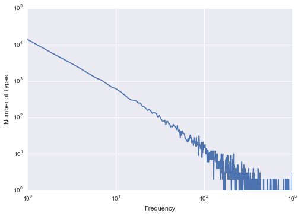

```python
import seaborn as sns

# plot the number of types (word identities) that have a particular frequency in the corpus
fdist = FreqDist(w for w in movie_reviews.words())
xs = [i for i in range(1000) if fdist.Nr(i) > 0]
ys = [fdist.Nr(i) for i in xs]
sns.plt.loglog(xs, ys);
sns.plt.xlabel('Frequency');
sns.plt.ylabel('Number of Types');
```

# Sentiment Classification

## Classify movie reviews into positive / negative

```python
movie_reviews.categories()
```

```
['neg', 'pos']
```

### Naive Bayes

$$P(C=\mbox{'pos'}\,|\, \vec{x}) = P(C=\mbox{'pos'}) \prod_{i=1}^n P(x_i\,|\,C=\mbox{'pos'})$$

| documents | features |  |  |  |  |  |  |
| --- | --- | --- | --- | --- | --- | --- | --- |
|  | , | the | . | a | and | of | to |
| 0 | 0 | 0 | 2 | 1 | 0 | 0 | 1 |
| 1 | 1 | 0 | 1 | 0 | 1 | 0 | 0 |
| 2 | 0 | 5 | 0 | 3 | 1 | 0 | 0 |

| documents | features |  |  |  |  |  |  |  |
| --- | --- | --- | --- | --- | --- | --- | --- | --- |
|  | 0 | 1 | 2 | 3 | 4 | 5 | 6 | ... |
| 0 | 0 | 0 | 2 | 1 | 0 | 0 | 1 | ... |
| 1 | 1 | 0 | 1 | 0 | 1 | 0 | 0 | ... |
| 2 | 0 | 5 | 0 | 3 | 1 | 0 | 0 | ... |

```python
import random

fileids = movie_reviews.fileids()
random.shuffle(fileids)
trn_fileids = [(fid, fid[:3]) for fid in fileids[100:]]
tst_fileids = [(fid, fid[:3]) for fid in fileids[:100]]

# turn review into bag of words for Naive Bayes
def review_features(fileid):
    words = [w for w in movie_reviews.words(fileid)]
    document_features = {w: 1 for w in words}
    return document_features
```

```python
from nltk.classify import NaiveBayesClassifier as NB
nb = NB.train((review_features(fileid), c)
              for fileid, c in trn_fileids)
```

```python
from nltk.classify import accuracy
accuracy(nb, [(review_features(fileid), c)
              for fileid, c in tst_fileids])
```

```
0.74
```

```python
nb.show_most_informative_features(10)
```

```
Most Informative Features
                  avoids = 1                 pos : neg    =     12.8 : 1.0
              astounding = 1                 pos : neg    =     12.2 : 1.0
               atrocious = 1                 neg : pos    =     11.8 : 1.0
             outstanding = 1                 pos : neg    =     11.2 : 1.0
                  turkey = 1                 neg : pos    =     11.2 : 1.0
               ludicrous = 1                 neg : pos    =     10.9 : 1.0
             fascination = 1                 pos : neg    =     10.8 : 1.0
               insulting = 1                 neg : pos    =     10.8 : 1.0
                   sucks = 1                 neg : pos    =     10.8 : 1.0
                  hudson = 1                 neg : pos    =     10.5 : 1.0
```

```python
import sklearn
from sklearn import pipeline
from sklearn import naive_bayes
from nltk.classify.scikitlearn import SklearnClassifier

pipeline = sklearn.pipeline.Pipeline([
        ('clf', sklearn.naive_bayes.MultinomialNB())])
sklearn_mnb = SklearnClassifier(pipeline)
sklearn_mnb.train((review_features(fileid), c)
                   for fileid, c in trn_fileids)
accuracy(sklearn_mnb, [(review_features(fileid), c)
                        for fileid, c in tst_fileids])
```

```
0.85
```

```python
from nltk.corpus import stopwords

stopwords_english = set(stopwords.words('english'))

def keep_feature(w):
    keep = w not in stopwords_english
    keep = keep and w.isalpha()
    return keep

def review_features(fileid):
    words = [w for w in movie_reviews.words(fileid)
             if keep_feature(w)]
    document_features = {w: 1 for w in words}
    return document_features
```

```python
nb = NB.train((review_features(fileid), c)
              for fileid, c in trn_fileids)
accuracy(nb, [(review_features(fileid), c)
              for fileid, c in tst_fileids])
```

```
0.71
```

```python
sklearn_mnb = SklearnClassifier(pipeline)
sklearn_mnb.train((review_features(fileid), c)
                   for fileid, c in trn_fileids)
accuracy(sklearn_mnb, [(review_features(fileid), c)
                       for fileid, c in tst_fileids])
```

```
0.86
```

# Feature Values: boolean, raw frequency, TFIDF

$$tfidf(t, d, D) = tf(t,d) \times idf(t, D) $$

$$idf(t, D) = \log{\frac{N}{|\{d \in D : t \in d\}|}}$$

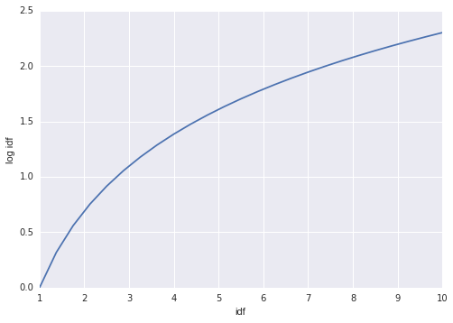

```python
import numpy as np

x = np.linspace(1, 10, 25)
y = [np.math.log(y) for y in np.linspace(1, 10, 25)]
sns.plt.plot(x, y);
sns.plt.ylabel('log idf');
sns.plt.xlabel('idf');
```

```python
pipeline = sklearn.pipeline.Pipeline([
            ('tfidf', TfidfTransformer(norm='l2')),
            ('clf', sklearn.svm.LinearSVC())])
sklearn_mnb = SklearnClassifier(pipeline)
sklearn_mnb.train((review_features(fileid), c)
                      for fileid, c in trn_fileids)
accuracy(sklearn_mnb, [(review_features(fileid), c)
                        for fileid, c in tst_fileids])
```

```
0.9
```

```python
from sklearn import tree
pipeline = sklearn.pipeline.Pipeline([
                ('tfidf', TfidfTransformer(norm='l2')),
                ('clf', tree.DecisionTreeClassifier())])
sklearn_mnb = SklearnClassifier(pipeline)
sklearn_mnb.train((review_features(fileid), c)
                  for fileid, c in trn_fileids)
accuracy(sklearn_mnb, [(review_features(fileid), c)
                        for fileid, c in tst_fileids])
```

```
0.67
```

# POS Tagging

### Assign part-of-speech tags (`NN`, `NNP`, `NNS`, `JJ`, `VB`) to words. Default `nltk.tag.pos_tag` works pretty well (MaxEnt Tagger), but others are also available:

- `nltk.tag.DefaultTagger(NN)`
- `nltk.tag.UnigramTagger()`
  - unigrams + backoff
- `nltk.tag.HiddenMarkovModelTagger`
- need annotated corpora (PennTreebank)

```python
# http://www.ling.upenn.edu/courses/Fall_2003/ling001/penn_treebank_pos.html
from nltk import pos_tag
pos_tag("this talk is pretty interesting".split())
```

```
[('this', 'DT'),
 ('talk', 'NN'),
 ('is', 'VBZ'),
 ('pretty', 'RB'),
 ('interesting', 'JJ')]
```

```python
from spacy.en import English
spc = English()
parsed_sent = spc("this talk is pretty interesting")
```

```python
for i, token in enumerate(parsed_sent):
    print(token.pos_, token.pos, token.orth_)
```

```
ADJ 1 this
NOUN 8 talk
VERB 16 is
ADV 3 pretty
ADJ 1 interesting
```

# Information Extraction

## Named Entity Recognition

### Named entities are bits of a sentence that correspond to some real world thing

- Organisation
- Geo Political Entity
- Time
- Person
- Location

```python
from spacy.en import English
spc = English()
```

```python
parsed = spc("Bill Gates is not the head of Microsoft (MSFT), valued at $234M.")
```

```python
list((w.orth_, w.pos_, w.ent_type_, w.dep_)
     for w in parsed)
```

```
[('Bill', 'NOUN', 'PERSON', 'compound'),
 ('Gates', 'NOUN', '', 'nsubj'),
 ('is', 'VERB', '', 'ROOT'),
 ('not', 'ADV', '', 'neg'),
 ('the', 'ADJ', '', 'det'),
 ('head', 'NOUN', '', 'attr'),
 ('of', 'ADP', '', 'prep'),
 ('Microsoft', 'NOUN', 'ORG', 'pobj'),
 ('(', 'PUNCT', '', 'punct'),
 ('MSFT', 'NOUN', 'ORG', 'appos'),
 (')', 'PUNCT', '', 'punct'),
 (',', 'PUNCT', '', 'punct'),
 ('valued', 'VERB', '', 'acl'),
 ('at', 'ADP', '', 'prep'),
 ('$', 'SYM', '', 'nmod'),
 ('234M.', 'NUM', 'MONEY', 'pobj')]
```

[figure not shown]

```python
import re

persons = set()
fileids = corpus.movie_reviews.fileids()
for fileid in fileids:
    doc = corpus.movie_reviews.raw(fileids=[fileid]
    doc = re.sub('\s+', ' ', doc))
    parsed = spc(doc)
    for w in parsed:
        if w.ent_type_ == 'PERSON'\
                and w.dep_ == 'compound':
            person = (w.orth_, w.head.orth_)
            persons.add(' '.join(person))
```

```python
# a more convenient way of extracting entities
persons = set()
fileids = corpus.movie_reviews.fileids()
for fileid in fileids:
    doc = corpus.movie_reviews.raw(fileids=[fileid]
    doc = re.sub('\s+', ' ', ))
    parsed = spc(doc)
    for ent in parsed.ents:
        if ent.label_ == 'PERSON'\
                and ent.end - ent.start > 1:
            persons.add(ent.text)
```

```python
import random
random.sample(persons, k=15)
```

```
['clint eastwood',
 'paul sorvino',
 'jonathan breck',
 'al hayes',
 'matthew letscher',
 'tommy lee jones',
 'david webb',
 "alan cohn's",
 'david kellogg',
 "willem dafoe's",
 'wolfgang amadeus',
 'scott glenn',
 'charlie brewster',
 'ivan reitman',
 'eric goldberg']
```

Use POS tags and named entity chunks

- `nltk.pos_tag`
- `nltk.ne_chunk`

```python
import nltk

persons_nltk = set()
fileids = random.sample(movie_reviews.fileids(), k=30)
for fileid in fileids:
    doc = corpus.movie_reviews.raw(fileids=[fileid]
    doc = re.sub('\s+', ' ', doc))
    for sent in movie_reviews.sents(fileids=[fileid]):
        chunks = nltk.ne_chunk(nltk.pos_tag(sent))
        for chunk in chunks.subtrees():
            if chunk.label() == 'PERSON'\
                    and len(chunk) > 1:
                persons.add(tuple(chunk.leaves()))
```

```python
# from nltk.corpus.reuters CATEGORY=Grain
list(random.sample(list(persons), k=15))
```

```
[(('John', 'NNP'), ('Danforth', 'NNP')),
 (('Treasury', 'NNP'), ('Bond', 'NNP')),
 (('Peter', 'NNP'), ('Baron', 'NNP')),
 (('Zhang', 'NNP'), ('Yan', 'NNP')),
 (('Export', 'NNP'), ('Enhancement', 'NNP')),
 (('Quaker', 'NNP'), ('Oats', 'NNP')),
 (('Jacques', 'NNP'), ('Chirac', 'NNP')),
 (('Economic', 'NNP'), ('Planning', 'NNP'), ('Agency', 'NNP')),
 (('Rahr', 'NNP'), ('Malting', 'NNP'), ('Co', 'NNP')),
 (('Tom', 'NNP'), ('Mulligan', 'NNP')),
 (('Dante', 'NNP'), ('Caputo', 'NNP')),
 (('Start', 'NNP'), ('Stcks', 'NNP')),
 (('Darwin', 'NNP'), ('E', 'NNP')),
 (('David', 'NNP'), ('Pryor', 'NNP')),
 (('Kika', 'NNP'), ('De', 'NNP'))]
```

```python
# from nltk.corpus.bible
list(random.sample(list(persons), k=15))
```

```
[(('Tyrus', 'NNP'), ('Nebuchadrezzar', 'NNP')),
 (('Eden', 'NNP'), ('Cherubims', 'NNP')),
 (('Saint', 'NNP'), ('Matthew', 'NNP')),
 (('Simon', 'NNP'), ('Peter', 'NNP')),
 (('Assuredly', 'NNP'), ('Solomon', 'NNP')),
 (('Curse', 'NNP'), ('David', 'NNP')),
 (('Anathema', 'NNP'), ('Maranatha', 'NNP')),
 (('Eglah', 'NNP'), ('David', 'NNP')),
 (('Hushai', 'NNP'), ('David', 'NNP')),
 (('Wherein', 'NNP'), ('God', 'NNP')),
 (('O', 'NNP'), ('Solomon', 'NNP')),
 (('James', 'NNP'), ('Bible', 'NNP')),
 (('Our', 'NNP'), ('Father', 'NNP')),
 (('Shimea', 'NNP'), ('David', 'NNP')),
 (('O', 'NNP'), ('Satan', 'NNP'))]
```

#### Stanford NER

http://nlp.stanford.edu/software/CRF-NER.shtml

# Information Extraction

## Dependency Parsing

### MALT Parser

- http://www.maltparser.org/

# The yellow fish that swims in the sea

[figure not shown]

# I ate the food with the fork

### I used the fork to eat the food

### I ate the food that had the fork

[figure not shown]

# I thought Tom Hanks was fantastic

[figure not shown]

```python
def is_person(entity):
    return ent.label_ == 'PERSON'\
        and ent.end - ent.start > 1

def is_opinion(person):
    is_opinion = False
    try:
        is_opinion =\
            next(ent.root.head.rights).dep_ == 'acomp'
    except StopIteration:
        pass

    is_opinion =\
        is_opinion and ent.root.dep_ == 'nsubj'
    return is_opinion
```

```python
opinions = set()
fileids = corpus.movie_reviews.fileids()
for fileid in fileids:
    doc = corpus.movie_reviews.raw(fileids=[fileid]
    doc = re.sub('\s+', ' ', doc))
    parsed = spc(doc)
    for ent in parsed.ents:
        if is_person(ent) and is_opinion(ent):
            left_child = next(ent.root.lefts)
            first = left_child.orth_.capitalize()
            last = ent.root.orth_.capitalize()
            right_of_head = next(ent.root.head.rights)
            opinions.add((first, last,
                          right_of_head.orth_))
```

```python
for first, last, adj in opinions:
    print(first, last, 'is', adj)
```

```
Andy Garcia is powerful
Actor Mccarthy is sleazy
Herbie Stempel is old
David Morse is competent
Even Broderick is dull
( Branagh is terrifying
Even Allen is pitiful
Kathleen Quinlan is annoying
David Arquette is impressive
Vanessa Redgrave is acknowledgeable
Brendan Fraser is great
Connie Britton is strung
David Lee is evil
( Isaacs is real
Rosanna Arquette is awful
Danny Glover is affable
Paul Giamatti is notable
Alec Baldwin is fat
Kenneth Branagh is able
```

```python
import nltk
import os

# load the example model from http://www.maltparser.org/mco/mco.html
mp_home = os.path.expanduser('~/Documents/PUB_NLP/maltparser-1.7.2/')
mp_model = os.path.expanduser('~/Documents/PUB_NLP/maltparser-1.7.2/models/engmalt.poly-1.7.mco')
mp = nltk.parse.malt.MaltParser(mp_home, mp_model)

# other models exist http://nlp.stanford.edu/software/stanford-dependencies.shtml
```

```python
dep_tree = mp.parse_tagged_sents(
    [nltk.pos_tag('I thought Tom Hanks was fantastic.'.split())])
graph = next(next(iter(dep_tree)))
print(graph.to_conll(style=4))
```

```
I	PRP	2	nsubj
thought	VBD	0	ROOT
Tom	NNP	4	nn
Hanks	NNP	6	nsubj
was	VBD	6	cop
fantastic.	NNP	2	ccomp
```

```python
graph
```

[figure not shown]

# Topic Modelling

### divide a corpus into topics based on distributional word usage

- topics are defined by how language is used, they don't necessarily correspond to what we think of topics

## distributional semantics

| features | features |  |  |  |  |  |  |
| --- | --- | --- | --- | --- | --- | --- | --- |
|  | 0 | 1 | 2 | 3 | 4 | 5 | 6 |
| 0 | 0 | 0 | 0 | 0 | 0 | 0 | 0 |
| 1 | 0 | 0 | 0 | 0 | 0 | 0 | 0 |
| 2 | 0 | 0 | 0 | 0 | 0 | 0 | 0 |
| 3 | 0 | 0 | 0 | 0 | 0 | 0 | 0 |
| 4 | 0 | 0 | 0 | 0 | 0 | 0 | 0 |
| 5 | 0 | 0 | 0 | 0 | 0 | 0 | 0 |
| 6 | 0 | 0 | 0 | 0 | 0 | 0 | 0 |

```python
import re
from nltk import corpus

def keep_token(token, tag):
    keep = re.search('(NN.*)|(VB.*)|(JJ)', tag)\
            is not None
    keep = keep and token.isalpha()
    return keep
```

```python
# preprocessing
pth = os.path.expanduser('~/Documents/PUB_nlp/lda.moviereviews.in.txt')
with open(pth, 'w') as out:
    for fileid in corpus.movie_reviews.fileids():
        sents = movie_reviews.sents(fileid)
        pos_tagged_sents = nltk.pos_tag_sents(sents)
        words = ['{}/{}'.format(
                    lmtz(w), tag)
                    for sent in pos_tagged_sents
                    for w, tag in sent
                 if keep_token(w, tag)]
        out.write(' '.join(words))
        out.write('\n')
```

```python
# you can run shell commands in notebook
# how awesome is that?
!wc -l ~/Documents/PUB_nlp/lda.moviereviews.in.txt
```

```
    2000 /Volumes/LocalDataHD/ml249/Documents/PUB_nlp/lda.moviereviews.in.txt
```

```python
# you can run shell commands in notebook
# how awesome is that?
!head -1 ~/Documents/PUB_nlp/lda.moviereviews.in.txt
```

```
moviemaking/VBG is/VBZ lot/NN being/VBG general/JJ manager/NN nfl/NN team/NN post/NN salary/NN cap/NN era/NN ve/VBP got/VBN know/VB allocate/VB resource/NNS dollar/NN spent/NN free/JJ agent/NN defensive/JJ tackle/NN is/VBZ le/JJR dollar/NN spend/VB linebacker/NNS safety/NNS center/NNS nfl/NN lead/NN…
```

```python
import gensim

# preprocess
dictionary = gensim.corpora.Dictionary()
pth = os.path.expanduser('~/Documents/PUB_nlp/lda.moviereviews.in.txt')
pth_out = os.path.expanduser('~/Documents/PUB_nlp/lda.moviereviews.in.mm')
with open(pth, 'r') as fh:
    bow_stream = (article.split(' ') for article in fh)
    lda_corpus = (dictionary.doc2bow(bow, allow_update=True)
                  for bow in bow_stream)
    gensim.corpora.MmCorpus.serialize(, lda_corpus)

lda_corpus = gensim.corpora.MmCorpus(pth_out)
```

```python
list(dictionary.items())[:10]
```

```
[(32048, 'lend/VB'),
 (19093, 'circumcision/NN'),
 (45821, 'wandering/JJ'),
 (31249, 'kristen/VBP'),
 (30694, 'request/NN'),
 (17072, 'exalts/NNS'),
 (11989, 'spotty/JJ'),
 (22098, 'hardcore/VBP'),
 (20559, 'mindset/VBP'),
 (31951, 'synonym/NN')]
```

```python
# train a TFIDF model
tfidf = gensim.models.TfidfModel(corpus=None,
                                 dictionary=dictionary,
                                 normalize=False)
corpus_tfidf = tfidf[lda_corpus]
```

```python
# train LDA model
import pandas as pd
print(pd.to_datetime('now'))
lda = gensim.models.LdaModel(corpus=corpus_tfidf,
                             id2word=dictionary,
                             num_topics=10,
                             chunksize=100,
                             iterations=100)
print(pd.to_datetime('now'))
```

```
2015-09-28 18:43:12
2015-09-28 18:43:31
```

```python
s, css = topics_html(lda.show_topics(num_topics=6, num_words=6, formatted=False))
display(HTML(css))
h = HTML(s); h
```

| **2.52e-03** | **2.38e-03** | **2.07e-03** | **1.73e-03** | **1.52e-03** | **1.30e-03** |
| --- | --- | --- | --- | --- | --- |
| **mulan** / NN | **star** / NN | **war** / NNS | **lucas** / NNS | **marie** / NN | **menace** / NN |
| **3.52e-03** | **2.62e-03** | **2.13e-03** | **1.97e-03** | **1.95e-03** | **1.89e-03** |
| **disney** / NN | **toy** / NN | **tarzan** / NN | **ape** / NNS | **murphy** / NN | **joe** / NN |
| **2.53e-03** | **2.44e-03** | **2.44e-03** | **1.83e-03** | **1.75e-03** | **1.50e-03** |
| **batman** / NN | **robin** / NN | **witch** / NN | **williams** / NNS | **blair** / NN | **frank** / NN |
| **3.37e-03** | **3.27e-03** | **3.15e-03** | **2.39e-03** | **2.27e-03** | **1.89e-03** |
| **horror** / NN | **scream** / NN | **killer** / NN | **godzilla** / NN | **seagal** / JJ | **trooper** / NNS |
| **2.42e-03** | **2.37e-03** | **1.84e-03** | **1.75e-03** | **1.62e-03** | **1.61e-03** |
| **jackie** / NN | **action** / NN | **wild** / NN | **van** / NN | **erin** / NN | **hong** / JJ |
| **3.37e-03** | **2.74e-03** | **2.10e-03** | **1.84e-03** | **1.64e-03** | **1.62e-03** |
| **spawn** / NN | **girl** / NNS | **myers** / NNS | **dillon** / NN | **shane** / NN | **stuart** / NN |

```python
lda_enwiki = gensim.models.LdaModel.load('enwiki/lda.gensim')
```

```python
s, css = topics_html(lda_enwiki.show_topics(num_topics=6, num_words=6, formatted=False))
display(HTML(css))
h = HTML(s); h
```

| **1.72e-02** | **1.36e-02** | **1.28e-02** | **1.23e-02** | **1.21e-02** | **1.19e-02** |
| --- | --- | --- | --- | --- | --- |
| **router** / nn | **liz** / nnp | **→** / nn | **whistle** / vbp | **amd** / nnp | **conrad** / nnp |
| **1.59e-02** | **1.41e-02** | **1.18e-02** | **1.17e-02** | **1.15e-02** | **1.06e-02** |
| **kuala_lumpur** / nnp | **porsche** / nnp | **bruce** / nnp | **capcom** / nnp | **tyre** / nns | **rand** / nnp |
| **2.50e-02** | **1.83e-02** | **1.55e-02** | **1.37e-02** | **1.19e-02** | **1.10e-02** |
| **wwe** / nnp | **square** / nns | **wrestling** / nnp | **smackdown** / nnp | **wrestling** / nn | **wrestling** / nnp |
| **4.14e-03** | **2.89e-03** | **2.57e-03** | **2.38e-03** | **2.36e-03** | **2.34e-03** |
| **use** / vbn | **system** / nn | **water** / nn | **species** / nns | **aircraft** / nn | **use** / nn |
| **2.92e-03** | **2.70e-03** | **2.67e-03** | **2.06e-03** | **2.00e-03** | **1.95e-03** |
| **city** / nn | **government** / nn | **state** / nn | **people** / nns | **law** / nn | **service** / nn |
| **4.99e-03** | **3.96e-03** | **3.33e-03** | **3.18e-03** | **3.11e-03** | **2.98e-03** |
| **album** / nn | **film** / nn | **band** / nn | **season** / nn | **song** / nn | **game** / nn |

# Deep Learning

### State of the art in distributional semantics, translation, text to speech ...

#### Socher on Recurrent NNs for NLP

- https://www.youtube.com/watch?v=tdLmf8t4oqM

#### The Unreasonable Effectiveness of Recurrent Neural Networks

- https://karpathy.github.io/2015/05/21/rnn-effectiveness/?utm_content=bufferdca1b&utm_medium=social&utm_source=facebook.com&utm_campaign=buffer
- http://nbviewer.ipython.org/gist/yoavg/d76121dfde2618422139

# NLP and Python

- Matti Lyra
- @mattilyra
- https://github.com/mattilyra/PUB_nlp
- http://paprr.co/

### Links

- http://nltk.org
- http://nltk.org/book
- http://www.radimrehurek.com/gensim
- http://scikit-learn.org/stable/
- http://www.spacy.io (http://nicschrading.com/project/Intro-to-NLP-with-spaCy/)